# diamonds_model

Jonny Nelson

18/01/2022

```r
library(janitor)
library(tidyverse)
library(fastDummies)
library(ggfortify)
library(GGally)
```

```r
library(mosaic)
diamonds <- read_csv("data/diamonds.csv")
```

```
## * `` -> ...1
```

```r
head(diamonds)
```

```
## # A tibble: 6 x 11
##    ...1 carat cut       color clarity depth table price     x     y     z
##   <dbl> <dbl> <chr>     <chr> <chr>   <dbl> <dbl> <dbl> <dbl> <dbl> <dbl>
## 1     1  0.23 Ideal     E     SI2      61.5    55   326  3.95  3.98  2.43
## 2     2  0.21 Premium   E     SI1      59.8    61   326  3.89  3.84  2.31
## 3     3  0.23 Good      E     VS1      56.9    65   327  4.05  4.07  2.31
## 4     4  0.29 Premium   I     VS2      62.4    58   334  4.2   4.23  2.63
## 5     5  0.31 Good      J     SI2      63.3    58   335  4.34  4.35  2.75
## 6     6  0.24 Very Good J     VVS2     62.8    57   336  3.94  3.96  2.48
```

# Understanding the variables

# price price in US dollars ($326–$18,823)

# carat weight of the diamond (0.2–5.01)

# cut quality of the cut (Fair, Good, Very Good, Premium, Ideal)

# color diamond colour, from J (worst) to D (best)

# clarity a measurement of how clear the diamond is (I1 (worst), SI2, SI1, VS2, VS1, VVS2, VVS1, IF (best))

# x length in mm (0–10.74)

# y width in mm (0–58.9)

# z depth in mm (0–31.8)

# depth total depth percentage = z / mean(x, y) = 2 * z / (x + y) (43–79)

# table width of top of diamond relative to widest point (43–95)

# Use ggpairs to show if carat is most strongly correlated with x, y and z

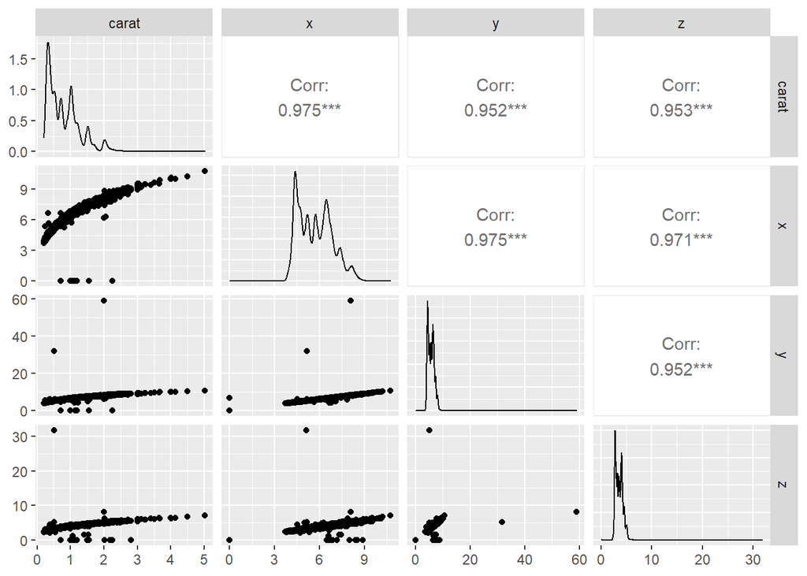

```r
diamonds_size <- diamonds %>%
  select(carat, x, y, z)

# diamonds_size

ggpairs(diamonds_size)
```

#### * We can see here that carat is highly correlated (always over 95%) with diamond carat.

#### * Carat is the diamond volume and x, y and z make up the dimensions of the diamond. As diamonds are all made from the exact same chemical structure of tetrahedrally bonded carbon the density will all be the same - assuming purity is 100%.

# 3. Drop x, y and z from data set as they are highly correlated to carat

```r
diamonds_clean <- diamonds %>%
  select(-c(x, y, z))

head(diamonds_clean)
```

```
## # A tibble: 6 x 8
##    ...1 carat cut       color clarity depth table price
##   <dbl> <dbl> <chr>     <chr> <chr>   <dbl> <dbl> <dbl>
## 1     1  0.23 Ideal     E     SI2      61.5    55   326
## 2     2  0.21 Premium   E     SI1      59.8    61   326
## 3     3  0.23 Good      E     VS1      56.9    65   327
## 4     4  0.29 Premium   I     VS2      62.4    58   334
## 5     5  0.31 Good      J     SI2      63.3    58   335
## 6     6  0.24 Very Good J     VVS2     62.8    57   336
```

# 4. We are interested in developing a regression model for the price of a diamond in terms of the possible predictor variables in the dataset.

## i. Use ggpairs() to investigate correlations between price and the predictors (this may take a while to run, don’t worry, make coffee or something).

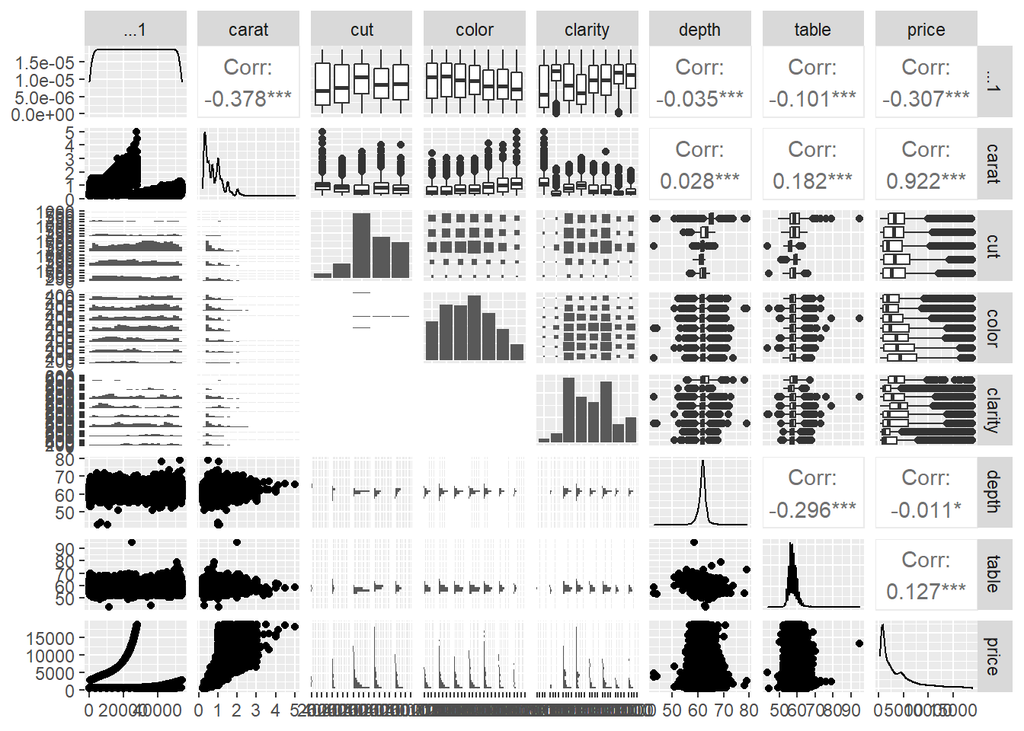

```r
ggpairs(diamonds_clean)
```

#### * Carat shows appears to be the most highly correlated to price of all variables with a correlation of 0.922, so will be visualised

## ii. Perform further ggplot visualisations of any significant correlations you find.

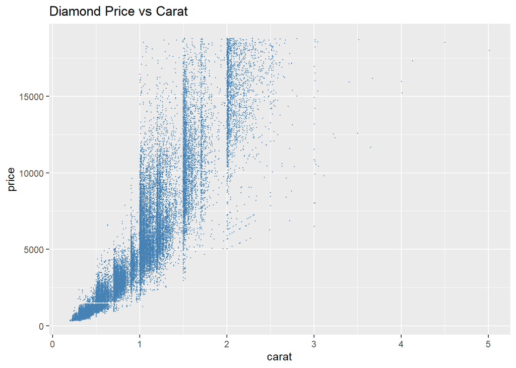

```r
diamonds_clean %>%
  ggplot(aes(x = carat, y = price)) +
  geom_point(colour = "steel blue", size = 0.25) +
  ggtitle("Diamond Price vs Carat")
```

```r
# Most diamonds in the data set appear to be a specific carat value. Makes sense in terms of selling to customers.
```

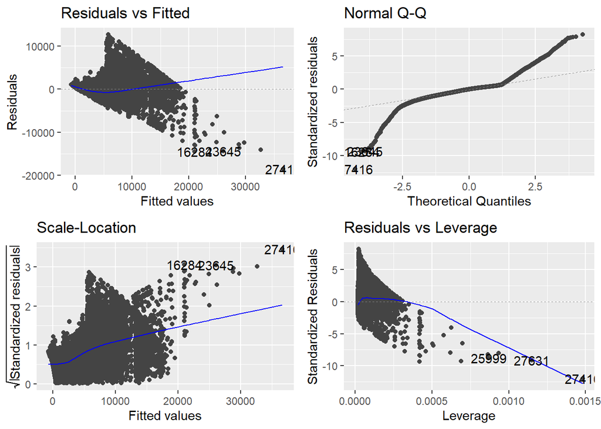

```r
simple_model <- lm(price ~ carat, data = diamonds_clean)

autoplot(simple_model)
```

#### * The Residuals vs Fitted graph and Scale-Location graph shows our data when plotted for price ~ carat, is hetroskedastic.

#### * The Normal Q-Q Plot shows that our data has heavy tails

# 5. Shortly we may try a regression fit using one or more of the categorical predictors cut, clarity and color, so let’s investigate these predictors. Investigate the levels of these predictors. How many dummy variables do you expect for each of them?

#### * Cut - Fair < Good < Very Good < Premium < Ideal - 4 Dummy variables

#### * Clarity - I1 < SI2 < SI1 < VS2 < VS1 < VVS2 < VVS1 < IF - 7 Dummy Variables

#### * Colour - D < E < F < G < H < I < J - 6 Dummy Variables

```r
unique(diamonds_clean$cut)
unique(diamonds_clean$clarity)
unique(diamonds_clean$color)
```

[output not shown]